# Panel Veri Analizi

Ramazan YALÇIN 121519821 - Assiye Sevde ÖZATA 121518964

22 Haziran, 2022

# 1.Panel Veri Analizi Nedir?

Panel veri analizi; yatay kesit verileri ile zaman serilerini bir araya getirmektedir. Buna göre daha çok aydınlatıcı veri, daha çok değişkenlik, değişkenler arasında daha az doğrusal bağlantı, daha çok serbestlik derecesi ve daha çok etkinlik sağlamaktadır. Zaman boyutuna sahip yatay kesit veriler bir başka ifade ile panel veriler kullanılarak oluşturulan panel veri modelleri yardımıyla veri seti ilişkilerinin tahmin edilmesi yöntemine “panel veri analizi” adı verilmektedir.

Panel veri analizinde genelde, yatay kesit birim sayısının $N$ dönem sayısından $T$ fazla $(N>T)$ olduğu durumla karşılaşılmaktadır. Genel olarak panel veri modeli;

$Y_{it} = \alpha + \sum_{i=1}^k \beta_k X_{kit} + u_{it},$ $\space$ $i=1,...,N;$ $\space$ $t=1,...T;$ $\space$ $k=1,2,...,q$

şeklinde yazılabilmektedir. Burada, $Y$ (bağımlı değişken), $X_k$ (bağımsız değişkenler), $\alpha$ sabit parametre, $\beta_k$ eğim parametreleri ve $u_{it}$ hata terimidir. $i$ alt indisi yatay kesit birimlerini (birey, firma, şehir, ülke gibi), $t$ alt indisi ise zamanı (gün, ay, yıl gibi) ifade etmektedir. Hata terimi $u_{it}$’ nin ortalamasının sıfır ve sabit varyanslı olduğu varsayılmaktadır. Bu modelde sabit ve eğim parametreleri hem birimlere hem de zamana göre değer almaktadır. Yukarıdaki panel veri modeline göre; tüm bağımsız değişkenlerin, yatay kesit birimlerinin hepsini aynı derecede etkilediğini öngörmektedir. Aksi bir durumda ise ifade edilen denklem yetersiz kalmaktadır. Bu noktada ortaya çıkan önemli bir konu, $(\beta_1)$’ in nasıl tanımlanacağıdır. Başlangıç noktası, tüm birimler için sabit tutulabilir veya farklı birimler için farklı başlangıç noktalarının olmasına izin verilebilir. Bu durumda, sabit ve tesadüfî etkili modeller olmak üzere iki yöntem ortaya çıkmaktadır. Sabit etkili model; başlangıç noktasının tüm yatay kesit birimleri için sabit bir değer alacağını öngörmektedir. Sabit etkili model, aşağıdaki eşitlik yardımıyla ifade edilmektedir.

$Y_{it} = \beta_{1i} + \beta_{2i}X_{2it} + \beta_{3i}X_{3it} + u_{it},$ $\space$ $\beta_{1j} \neq \beta_{1i}$

Tesadüfî etkiler modeli ise başlangıç noktasını rassal değişken olarak tanımlamaktadır. Buna göre başlangıç noktaları, $\beta_1$ sabit değeri ile sıfır ortalamalı $u_{it}$ rassal değişkeninin toplamından oluşmaktadır. Tesadüfî etkiler modeli, aşağıda tanımlanan denklem modeliyle ifade edilmektedir.

$Y_{it} = \beta_{1i} + \beta_{2i}X_{2it} + \beta_{3i}X_{3it} + u_{it},$ $\space$ $\beta_{1j} \neq \beta_{1i} + \mu_i$

Parametre tahmini Havuzlanmış En Küçük Kareler tahmin edicisi aşağıdaki formülde olacak şekilde hesaplanmaktadır. Havuzlanmış En Küçük Kareler Yöntemi birim ya da zaman etkilerinin var olmadığı durumlarda sabit ve eğim parametrelerinin sabit olduğu varsayımları altında tahmin yapmaktadır.

$\hat{\beta} = [\sum_{i=1}^N \sum_{t=1}^T X_{it}^{'}X_{it}]^{-1} . [\sum_{i=1}^N \sum_{t=1}^T X_{it}^{'}X_{it}]$

# 2.Uygulama Hazırlık

## Kütüphane Yüklemeleri

Çalışmamızda kullanacağımız kütüphane yüklemeleri aşağıdaki gibidir.

```r
library(tidyverse)
library(dplyr)
library(corrplot)
library(gplots)
library(foreign)
library(plm)
library(lmtest)
```

## Veri Seti

Veri setimizin tanımlamasını yapıyoruz.

```r
#weapons <- read_csv("C:/Users/sevde/OneDrive/Masaüstü/weapons.csv")
weapons <- read_csv("C:/Users/Ramazan/Desktop/Panel Veri/weapons.csv")
```

Veri, Amerika Birleşik Devletleri’ndeki 50 eyalete ait 1977-1999 yılları arasında cinayet oranı, soygun oranı, suç oranı, hapsedilme oranı, nüfus yüzdesi, ortalama devlet geliri ve eyalet nüfusu değişkenlerinden oluşmaktadır.

Veri 1150 gözlem, 13 değişken, 23 yıl ve 50 eyaletten oluşmaktadır.

Verideki değişkenlerin açıklaması aşağıdadır.

- **mur**-Cinayet oranı (100.000’de bir olay)
- **rob**-Soygun oranı (100.000’ de bir olay)
- **vio**-Şiddet içeren suç oranı (100.000’de bir olay)
- **shall**-Devletin o yıl yürürlükte olan bir taşıma yasası varsa 1, aksi takdirde 0
- **incarc_rate**-Bir önceki yıl eyaletteki hapsedilme oranı (100.000 kişi başına hükümlü mahkum; önceki yıl için değer)
- **pm1029**-10 ile 29 yaşları arasındaki erkek eyalet nüfusunun yüzdesi
- **pw1064**-Beyaz olan ve 10 ile 64 yaş arasındaki eyalet nüfusunun yüzdesi
- **pb1064**-Siyahi olan ve 10 ile 64 yaş arasındaki eyalet nüfusunun yüzdesi
- **avginc**-Ortalama devlet geliri (1983’te bin dolar olarak)
- **density**-Mil kare başına nüfus, bin olarak
- **pop**-Eyalet nüfusu, milyon
- **year**-Yıl (1977-1999)
- **stateid**-Devlet tanımlayıcısı

Veri setimizin değişken isimleri aşağıdaki gibidir.

```r
names(weapons)
```

```
##  [1] "stateid"     "year"        "vio"         "mur"         "rob"
##  [6] "incarc_rate" "pb1064"      "pw1064"      "pm1029"      "pop"
## [11] "avginc"      "density"     "shall"
```

```r
summary(weapons)
```

```
##    stateid               year           vio              mur
##  Length:1150        Min.   :1977   Min.   :  47.0   Min.   : 0.200
##  Class :character   1st Qu.:1982   1st Qu.: 281.5   1st Qu.: 3.600
##  Mode  :character   Median :1988   Median : 437.5   Median : 6.300
##                     Mean   :1988   Mean   : 472.2   Mean   : 6.833
##                     3rd Qu.:1994   3rd Qu.: 635.2   3rd Qu.: 9.600
##                     Max.   :1999   Max.   :1244.3   Max.   :20.300
##       rob         incarc_rate        pb1064            pw1064
##  Min.   :  6.4   Min.   : 19.0   Min.   : 0.2482   Min.   :23.52
##  1st Qu.: 70.2   1st Qu.:113.0   1st Qu.: 2.1603   1st Qu.:60.29
##  Median :122.4   Median :183.0   Median : 3.9651   Median :65.34
##  Mean   :143.7   Mean   :211.5   Mean   : 4.9652   Mean   :63.71
##  3rd Qu.:188.5   3rd Qu.:285.0   3rd Qu.: 6.4426   3rd Qu.:69.29
##  Max.   :684.0   Max.   :736.0   Max.   :26.9796   Max.   :76.53
##      pm1029           pop              avginc          density
##  Min.   :12.51   Min.   : 0.4027   Min.   : 8.555   Min.   :0.0007071
##  1st Qu.:14.66   1st Qu.: 1.2424   1st Qu.:11.897   1st Qu.:0.0315201
##  Median :15.89   Median : 3.2889   Median :13.316   Median :0.0795801
##  Mean   :16.09   Mean   : 4.9006   Mean   :13.623   Mean   :0.1636141
##  3rd Qu.:17.53   3rd Qu.: 5.7378   3rd Qu.:15.162   3rd Qu.:0.1682232
##  Max.   :22.35   Max.   :33.1451   Max.   :23.647   Max.   :1.0976428
##      shall
##  Min.   :0.0000
##  1st Qu.:0.0000
##  Median :0.0000
##  Mean   :0.2478
##  3rd Qu.:0.0000
##  Max.   :1.0000
```

Veri setimizin özet istatistiği yukarıdaki gibidir.

## Kayıp Veri Analizi

```r
NROW(na.omit(weapons))
```

```
## [1] 1150
```

Verimizde eksik değer bulunmamaktadır.

# 3.Dengeli Panel - Dengesiz Panel

Panel verilerle çalışıldığında, her bir birim tüm zamanlar boyunca gözlenmişse “dengeli panel”; bazı birimler için bazı zamanlar kayıpsa “dengesiz panel” olarak adlandırılmaktadır.

```r
weapons %>% count(stateid)
```

```
## # A tibble: 50 x 2
##    stateid     n
##    <chr>   <int>
##  1 AK         23
##  2 AL         23
##  3 AR         23
##  4 AZ         23
##  5 CA         23
##  6 CO         23
##  7 CT         23
##  8 DE         23
##  9 FL         23
## 10 GA         23
## # ... with 40 more rows
```

Verimiz dengeli panel veri yapısına sahiptir. ABD’de her bir eyaleti her yıl bir kez olmak üzere 23 kez gözlemliyoruz.

# 4.Korelasyon

Korelasyon iki değişken arasındaki doğrusal ilişkinin derecesini ve yönünü açıklayan bir kavramdır. İlişki hesaplamalarında veya ilişki analizlerinde bu kavram sıklıkla kullanılmaktadır. Yapılan analiz ve hesaplamaların nihai amacı ele alınan değişkenler arasındaki ilişkinin gücünü ve yönünü ortaya koymak için standart bir değer elde etmektedir. Bu standart değer korelasyon katsayısı olarak adlandırılmakladır. Korelasyon katsayısı R ile gösterilmektedir.

```r
corrl<-cor(weapons[,3:12])
corrl
```

```
##                    vio         mur        rob  incarc_rate      pb1064
## vio          1.0000000  0.70744229  0.8528373  0.541705635  0.35971990
## mur          0.7074423  1.00000000  0.6264604  0.391961033  0.46200479
## rob          0.8528373  0.62646045  1.0000000  0.318500077  0.33052950
## incarc_rate  0.5417056  0.39196103  0.3185001  1.000000000  0.38678061
## pb1064       0.3597199  0.46200479  0.3305295  0.386780611  1.00000000
## pw1064      -0.3504384 -0.46250375 -0.3187807 -0.361497706 -0.97466958
## pm1029      -0.1782223  0.18166544 -0.1037137 -0.523348475  0.03865878
## pop          0.5410316  0.38495083  0.6493391  0.236904915  0.14213137
## avginc       0.3010535 -0.10121138  0.3592404  0.351626351  0.14714389
## density      0.2215428 -0.07574882  0.3673820 -0.006658938  0.08747197
##                  pw1064      pm1029        pop      avginc      density
## vio         -0.35043839 -0.17822233  0.5410316  0.30105350  0.221542840
## mur         -0.46250375  0.18166544  0.3849508 -0.10121138 -0.075748817
## rob         -0.31878075 -0.10371372  0.6493391  0.35924041  0.367382011
## incarc_rate -0.36149771 -0.52334847  0.2369049  0.35162635 -0.006658938
## pb1064      -0.97466958  0.03865878  0.1421314  0.14714389  0.087471975
## pw1064       1.00000000 -0.03766792 -0.1546072 -0.05046704 -0.075059488
## pm1029      -0.03766792  1.00000000 -0.1044715 -0.52686139 -0.203811149
## pop         -0.15460720 -0.10447148  1.0000000  0.26322274  0.201468013
## avginc      -0.05046704 -0.52686139  0.2632227  1.00000000  0.476453893
## density     -0.07505949 -0.20381115  0.2014680  0.47645389  1.000000000
```

Cinayet oranına (mur) bakıldığında şiddet içeren suç oranı (vio) ile yüksek bir korelasyona sahip olduğunu görmekteyiz. Mil kare başına nüfus (density) ile ise negatif ilişkili ve çok düşük korelasyona sahiptir.

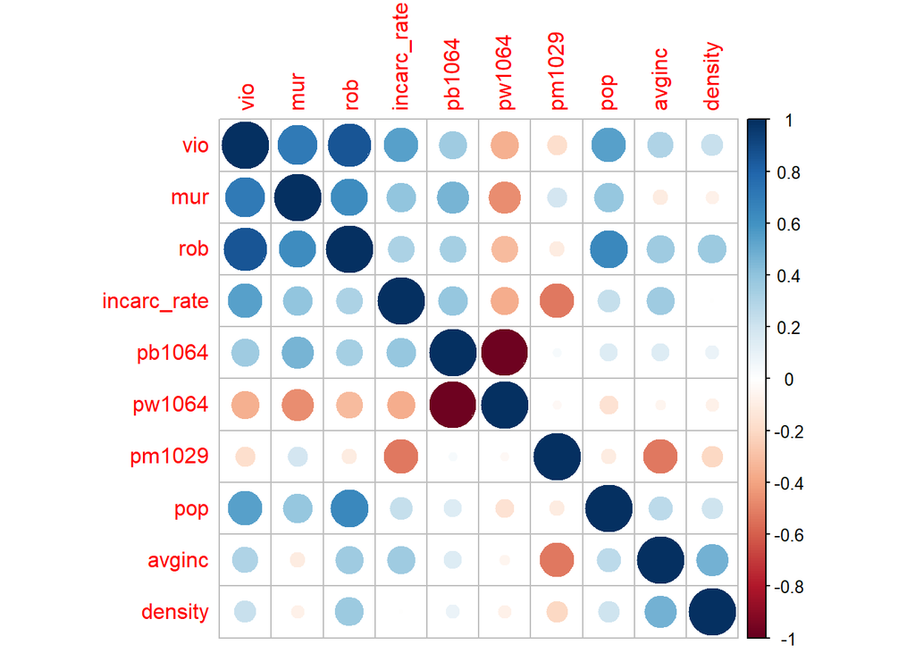

```r
corrplot(corrl)
```

Görsel olarak baktığımızda, pozitif korelasyonlar mavi ve negatif korelasyonlar kırmızı renkte gösterilmiştir. Dairenin renk yoğunluğu ve boyutu korelasyon katsayılarıyla bağlantılı olup orantılıdır.

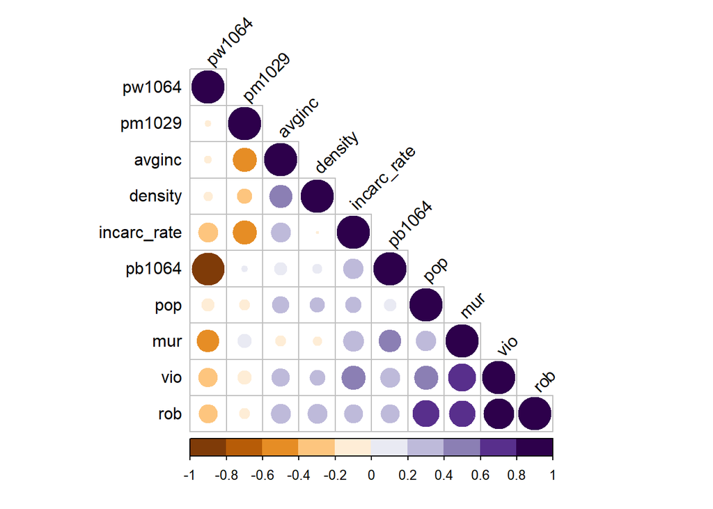

```r
corrplot(corrl, type = 'lower', order = 'hclust', tl.col = 'black',
         cl.ratio = 0.2, tl.srt = 45, col = COL2('PuOr', 10))
```

Bir önceki grafiğe benzer olarak farklı bir formatı da yukarıdaki gibidir.

# 5.İçsellik - Dışsallık

“İçsellik”, bağımsız değişkenler ile hata teriminin korelasyonlu olması olarak ve “dışsallık”, bağımsız değişkenler ile hata teriminin korelasyonlu olmaması olarak tanımlanmaktadır.

# 6.Heterojenlik

Panel veri analizlerinde kullanılan bireyler, firmalar, ülkeler, şehirler gibi birimler genelde heterojendir. Bu heterojenliği hesaba katmamak, ilgilenilen parametrelerin tutarsız tahminlerine sebep olmaktadır. Heterojenliği modele yansıtmanın en kolay yolu sabit ve/veya eğim parametrelerinin heterojen olduğunu varsaymak ve ona göre tahmin yöntemi belirlemektir.

Panel verimiz için, cinayet oranı, soygun oranı, şiddet suç oranı, hapsedilme oranı, nüfus vb. için heterojenlik oluşabilir.

R’da, “gplots” kütüphanesinde bulunan “plotmeans” fonksiyonu kullanılarak heterojenliği görselleştirebiliriz.

## 6.1.Heterojenlik Cinayet Oranı (Mur) ile Eyalet

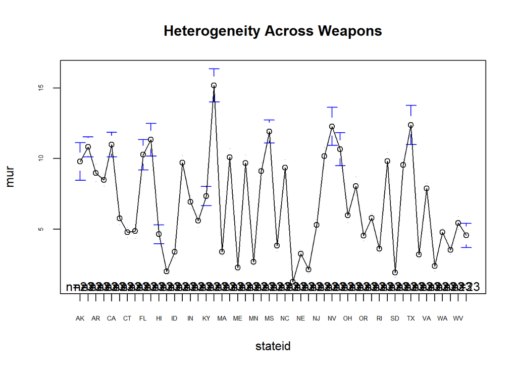

```r
plotmeans(mur~stateid , main = 'Heterogeneity Across Weapons', data = weapons,cex.axis=0.5)
```

## 6.2.Heterojenlik Cinayet Oranı (Mur) ile Yıl

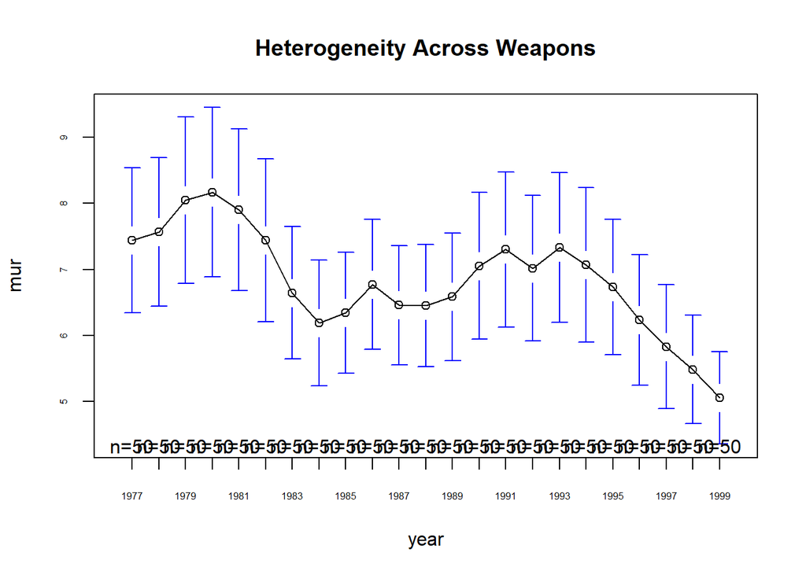

```r
plotmeans(mur~year , main = 'Heterogeneity Across Weapons', data = weapons,cex.axis = .5)
```

# 7.Görselleştirme

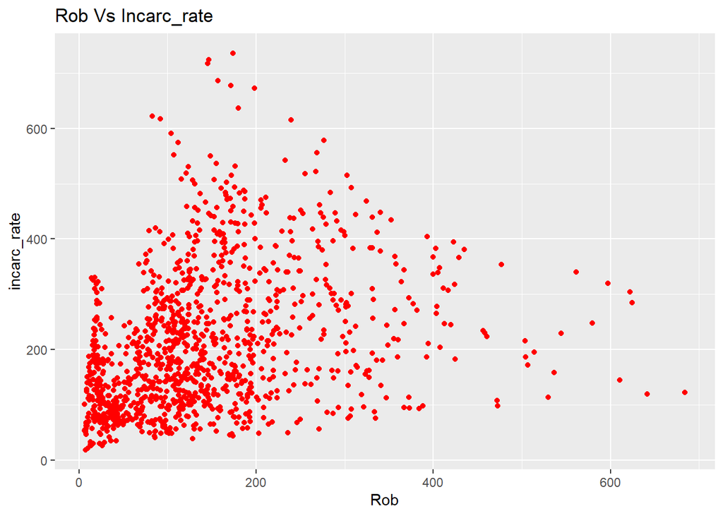

```r
ggplot() + geom_point(aes(weapons$rob, weapons$incarc_rate),colour = 'red') + ggtitle('Rob Vs Incarc_rate') +
xlab('Rob') + ylab('incarc_rate')
```

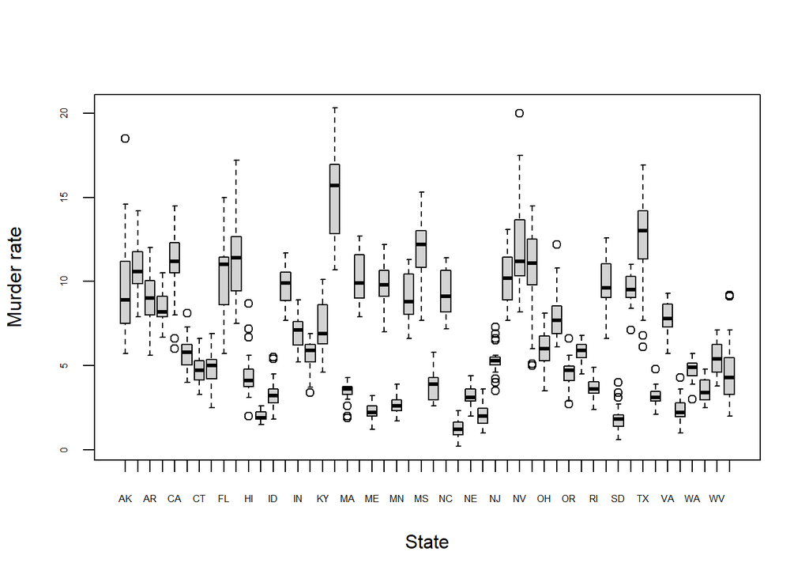

```r
boxplot(mur ~ stateid,
        data = weapons,
        xlab = "State",
        ylab = "Murder rate",
        cex.axis = .5)
```

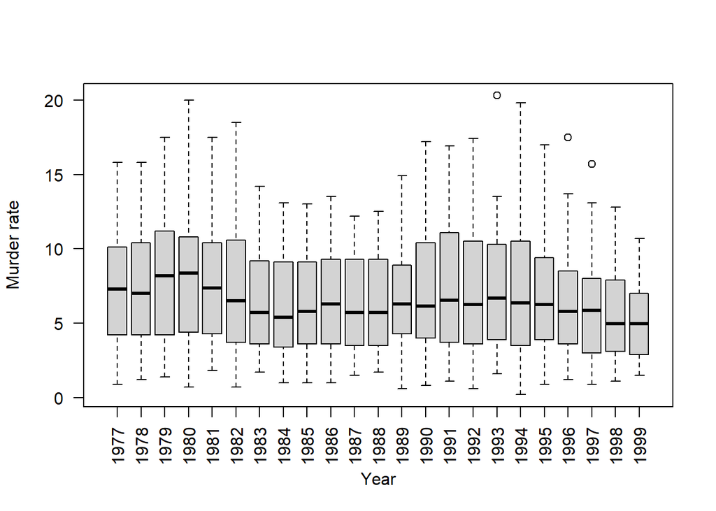

```r
boxplot(mur ~ year,
        data = weapons,
        xlab = "Year",
        ylab = "Murder rate",
        las = 2)
```

Grafikler, verimizdeki varyasyonun iki kaynağını göstermektedir: duruma göre varyasyon ve zaman içindeki varyasyon. Yalnızca bir yıllık verileri gözlemleyecek olsaydık, sonucumuzdaki tek değişiklik eyaletler arasındaki farklılıklardan olurdu. Ancak buradaki verilerimiz panel yapıya sahip olduğu için cinayet oranlarında da zaman içinde farklılıklar var.

# 8.Tahmin Methodları

Panel veriler, zamansal ve uzamsal boyutlar hakkında bilgiler içerir. Zamansal boyut, ay, çeyrek, yıl gibi tekrarlanan ölçümlerin yapıldığı dönem; uzamsal boyut ise kişi, firma, devlet gibi gözlemlerin birimidir. Panel verilerin genel regresyon modeli şu şekilde ifade edilebilir:

$y_{it}: \beta_0+\beta_{1x_{it,1}}+...+\beta_{kx_{it,k}}+v_{it},$ $\space$ $i=1,...,N;$ $\space$ $t=1,...,K$

**$i$** gözlem birimi,

**$t$** zaman periyodu,

**$k$** k’ıncı açıklayıcı değişkeni gösterir,

**$\beta_0$** kesişme noktasıdır,

**$\beta_K$** her bir açıklayıcı değişkenin katsayısıdır,

**$v_{it}$** hata terimidir.

Yukarıdaki denklemde sözde bileşik hata terimi, $v_{it}$, iki bileşene ayrılabilir: $a_{i}$ bir kesit birimine özgü hata ve $u_{it}$ bir özel hata.

$v_{it}=a_{i}+u_{it}$

Kesit birimine özgü hata $a_{i}$, zamanla değişmez ve kendine özgü hata $u_{it}$, kesit birimlerine ve zamana göre değişir. Hata terimlerini iki parçaya ayırmanın faydası, eğer panel verileri kullanarak bunların bir kısmını ortadan kaldırabilirsek ölçülmemiş birime özgü faktörlerin neden olduğu ihmal edilen değişken yanlılığı endişelerini en aza indirmek açısından daha iyi durumda olacağımızdır.

Yukarıdaki iki denklem dönüştürülebilir.

$y_{it}: \beta_0+\beta_{1x_{it,1}}+...+\beta_{kx_{it,k}}+a_{i}+u_{it}$

Yukarıdaki denklem, bir hata bileşeni modeli olarak adlandırılır. Zamana bağlı ve birime özgü hata $a_i$ gözlemlenmeyen bir faktördür. Hata bileşeni modellerinin tahmin yöntemleri, hata teriminin nasıl ele alınacağına göre sınıflandırılır. Havuzlanmış EKK modeli, onu diğer hata türlerinden ayırt etmez oysa sabit etkiler modeli bunu tahmin edilecek katsayılar olarak görür ve rastgele etkiler modeli bunu rastgele değişkenler olarak ele alır.

# 9.Regresyon Modeli

Regresyon modelini inceleyelim.

```r
reg <- lm(mur ~ vio+rob+incarc_rate+pop+pb1064+pw1064+pm1029+avginc+density, data = weapons)
summary(reg)
```

```
##
## Call:
## lm(formula = mur ~ vio + rob + incarc_rate + pop + pb1064 + pw1064 +
##     pm1029 + avginc + density, data = weapons)
##
## Residuals:
##     Min      1Q  Median      3Q     Max
## -6.6275 -1.3127 -0.0847  1.1312 10.2163
##
## Coefficients:
##               Estimate Std. Error t value Pr(>|t|)
## (Intercept) -8.9426790  2.5011308  -3.575 0.000364 ***
## vio          0.0061213  0.0005510  11.109  < 2e-16 ***
## rob          0.0112355  0.0013078   8.591  < 2e-16 ***
## incarc_rate  0.0063725  0.0007645   8.335  < 2e-16 ***
## pop          0.0077206  0.0148654   0.519 0.603604
## pb1064       0.3703701  0.0776226   4.771 2.07e-06 ***
## pw1064       0.1114488  0.0383018   2.910 0.003687 **
## pm1029       0.4634724  0.0503669   9.202  < 2e-16 ***
## avginc      -0.4548707  0.0389082 -11.691  < 2e-16 ***
## density     -1.9222298  0.3169250  -6.065 1.79e-09 ***
## ---
## Signif. codes:  0 '***' 0.001 '**' 0.01 '*' 0.05 '.' 0.1 ' ' 1
##
## Residual standard error: 1.965 on 1140 degrees of freedom
## Multiple R-squared:  0.7283, Adjusted R-squared:  0.7261
## F-statistic: 339.5 on 9 and 1140 DF,  p-value: < 2.2e-16
```

Yukarıda 1977-1999 yılları arasını kapsayan panel veride EKK yöntemi ile tahminleme yapılmıştır. Analiz sonuçlarına göre bu dönemde eyaletlerde cinayet oranındaki varyasyonu açıklaması bakımından eyalet nüfusu değişkeni hariç diğer değişkenlerin istatistiksel olarak anlamlı bir etkisi olduğu gözlemlenmektedir.

Şiddet suç oranı, soygun oranı, hapsedilme oranı, eyalet nüfusu, 10 ile 64 yaş arasındaki beyaz olan eyalet nüfusunun yüzdesi, 10 ile 64 yaş arasındaki siyah eyalet nüfusunun yüzdesi ve 10 ile 29 yaşları arasındaki erkek değişkenlerinin cinayet oranı üzerinde pozitif etkisi olduğu gözlemlenmiştir.

# 10.Havuzlanmış En Küçük Kareler

Havuzlanmış EKK tahmini, panel veri üzerinde çalışan bir EKK tekniğidir. Panel veri, zaman ve kesit boyutları bilgilerini içerir ancak havuzlanmış EKK panel verilerin bu bilgilerini dikkate almaz. Bu nedenle bireye özgü tüm etkiler tamamen göz ardı edilir.

Havuzlanmış EKK için panel veri denklemi şu şekilde olacaktır:

$C:\beta_0+\beta_{1}*Q_{it}+\beta_{2}*PF_{it}+\beta_{3}*Lf_{it}+V_{it}$

Varsayımlar:

1. Regresyon katsayıları tüm silehlar için aynıdır, yani $\beta_0$, $\beta_1$, $\beta_2$, $\beta_3$ tüm silehlar için aynıdır.
2. Hatalar açıklayıcı değişkenlerin hiçbiriyle ilişkili değildir, $cov(V_{it}, X_{it})=0$. Hata ve tahmin edici arasındaki kovaryans sıfır olmadığında tahmin edici içsel olacaktır ve sonuç olarak; kesişme, katsayı yanlı ve tutarsız olacaktır.
3. Hata terimleri normal olarak dağıtılır $\epsilon \sim N(0, \sigma^2)$ yani ortalama sıfıra ve hata terimlerinin varyansı $\sigma^2$’ ye eşittir.

Hipotezlerimiz aşağıdaki gibidir:

$H_0$: Havuzlanmış EKK uygun tahmin edici değildir.

$H_1$: Havuzlanmış EKK uygun tahmin edicidir.

```r
pool <-plm(mur ~ vio+rob+incarc_rate+pop+pb1064+pw1064+pm1029+avginc+density, data = weapons, index=c("stateid", "year"), model = "pooling")
summary(pool)
```

```
## Pooling Model
##
## Call:
## plm(formula = mur ~ vio + rob + incarc_rate + pop + pb1064 +
##     pw1064 + pm1029 + avginc + density, data = weapons, model = "pooling",
##     index = c("stateid", "year"))
##
## Balanced Panel: n = 50, T = 23, N = 1150
##
## Residuals:
##      Min.   1st Qu.    Median   3rd Qu.      Max.
## -6.627468 -1.312705 -0.084719  1.131169 10.216324
##
## Coefficients:
##                Estimate  Std. Error  t-value  Pr(>|t|)
## (Intercept) -8.94267901  2.50113077  -3.5755 0.0003643 ***
## vio          0.00612128  0.00055102  11.1089 < 2.2e-16 ***
## rob          0.01123553  0.00130782   8.5910 < 2.2e-16 ***
## incarc_rate  0.00637245  0.00076450   8.3354 < 2.2e-16 ***
## pop          0.00772064  0.01486540   0.5194 0.6036040
## pb1064       0.37037007  0.07762261   4.7714 2.066e-06 ***
## pw1064       0.11144876  0.03830184   2.9097 0.0036874 **
## pm1029       0.46347235  0.05036691   9.2019 < 2.2e-16 ***
## avginc      -0.45487068  0.03890818 -11.6909 < 2.2e-16 ***
## density     -1.92222978  0.31692505  -6.0653 1.790e-09 ***
## ---
## Signif. codes:  0 '***' 0.001 '**' 0.01 '*' 0.05 '.' 0.1 ' ' 1
##
## Total Sum of Squares:    16193
## Residual Sum of Squares: 4399.8
## R-Squared:      0.72829
## Adj. R-Squared: 0.72615
## F-statistic: 339.522 on 9 and 1140 DF, p-value: < 2.22e-16
```

**p-değeri:** Genel model için p-değeri 0.05’e eşit veya daha küçük olduğunda istatistiksel olarak önemlidir. Sıfır hipotezine karşı güçlü kanıtlar olduğunu gösterir veya yalnızca sıfır hipotezinin doğru olma olasılığının 0.05’ten küçük olduğunu belirtir. Yani sıfır hipotezini reddedip alternatif hipotezi kabul edebileceğimizi söyleyebiliriz.

Sonuç olarak burada, havuzlanmış EKK’in iyi bir tahmin edici olabileceğini ancak kabul edilemeyeceğini söyleyebiliriz, çünkü havuzlanmış EKK, devlet tanımlayıcıları veya yıllar arasındaki heterojenliği dikkate almaz.

1. Analiz sonucunda eyalet nüfusu değişkeni hariç diğer değişkenlerin bireysel etkileri yani p değerleri 0.05’in altında olduğu için önemlidir.

**$R^2$:** Tahmin ediciler ile yanıt arasındaki ilişkinin gücünü belirler. Modelin veya regresyon çizgisinin verilere ne kadar uyduğunu gösterir.

2. Burada $R^2$, uygunluk ölçüsünün iyi olduğunu gösteren 0.72829’a eşittir.

**Düzeltilmiş $R^2$:** Değerlendirme için daha güvenilir ve doğrudur. Önemsiz tahmin ediciler eklense bile $R^2$ arttıkça, ancak önemsiz tahmin ediciler eklendikçe düzeltilmiş $R^2$ azalır. Esas olarak, farklı sayıda değişkene sahip bir modeli karşılaştırırken kullanılır.

3. Burada Düzeltilmiş $R^2$, modelin güvenilir olduğunu gösteren 0.72615’e eşittir.

**Havuzlanmış EKK’nın p-değeri 0.05’ten az olsa da, $R^2$ ve Düzeltilmiş $R^2$ genel doğruluğun iyi olduğunu, modelin kullanıma uygun olduğunu gösterse bile heterojenliği tamamen göz ardı ettiği için bu modele güvenemeyiz.**

Regresyon çıktısında görünen diğer önemli faktörler şunlardır:

**1. Standart Hata:** Modelin kesinliğinin bir ölçüsüdür ve regresyon modelinin ortalama hatasını yansıtır. Bir istatistiğin standart hatası, istatistiksel bir örnek popülasyonunun yaklaşık standart sapmasıdır. Bir örnekleme dağılımının bir popülasyonu ne kadar kesin olarak temsil ettiğini veya orada gerçek bir değerden ne kadar sapma olduğunu ölçer.

**2. t-İstatistiği:** t-istatistiği, sıfır hipotezinin desteklenip desteklenmediğini belirlemek için bir t-testinde kullanılır. Örnek boyutu küçük olduğunda veya popülasyon standart sapması bilinmediğinde kullanılır. T testi, iki grubun ortalamaları arasında belirli özelliklerle ilişkili olabilecek anlamlı bir fark olup olmadığını belirlemek için kullanılan bir tür çıkarımsal istatistiktir.

Örneğin, popülasyon standart sapması bilinmiyorsa, t-istatistiği, örnek ortalamalarının bir örnekleme dağılımından popülasyon ortalamalarının tahmin edilmesinde kullanılır. Hipotez testi yapılırken p-değeri ile birlikte kullanılır.

# 11.Sabit Etkili Model

Sabit etkili bir model, bireyler (grup ve varlık) arasında aynı eğimleri ve sabit varyansı varsayarak veya aynı panel boyunca heterojenliğin sabit olduğunu varsayarak, kesişimlerdeki bireysel farklılıkları inceler.

## 11.1.En Küçük Kareler Kukla Değişkeni Model (LSDV)

En küçük kareler kukla değişken modeli (LSDV), sabit etki modelini tahmin etmek için kukla değişkenler kullanır.

LSDV, tahmin edilmesi ve yorumlanması biraz daha kolay olduğu için yaygın olarak kullanılmaktadır. LSDV, her bir kukla değişken modelden bir serbestlik derecesini ortadan kaldırdığından, panel verisi nispeten daha az hataya ve daha fazla zaman periyoduna sahip olduğunda en iyi şekilde çalışır.

Ancak tahmin edilecek parametre sayısı arttıkça daha karmaşık hale gelir. Birçok kukla değişken içerdiğinde, bu durumda LSDV de serbestlik derecelerini kaybeder ancak daha az verimli tahmin ediciler döndürür ve burada “within” modelle gitmek daha iyidir.

Genel LSDV modeli:

$y_{it}=\beta_0+(\delta_{1}D_{1}+...+\delta_{i-1}D_{i-1})+(\theta_{1}T_{1}+...+\theta_{t-1}T_{t-1})+(\beta_{1}x_{it,1}+...+\beta_{k}x_{it,k})+u_{it}$

Burada,

- $D_i$, biri hariç her bir kesit birimi için kukla değişkenlerdir.
- $T_t$, biri hariç her bir zaman periyodu için kukla değişkenlerdir.

Bir kukla değişkenle uğraşırken çoklu doğrusal bağlantı dikkate alınması gereken önemli bir faktördür. Çoklu doğrusal bağlantı, tahmin edicilerin kendileri ilişkilendirildiğinde ortaya çıkar ve bu da kukla değişken tuzağına yol açar.

R programlamada LSDV’yi tahmin etmek için “lm” paketini kullanıyoruz. Kukla değişkenler atamak için factor() fonksiyonunu kullanırız. Factor() fonksiyonu, bir vektörü faktör olarak kodlar ve mod karakterinin bir “levels” öz niteliği ve benzersiz (!anyDuplicated(.)) entries. ile x uzunluğunda bir tamsayı koduna sahip “factor” sınıfının bir nesnesini döndürür. Verileri kategorize eder ve seviyeler halinde saklar.

LSDV tahmini için “lm” paketini kullandığımızdan, kukla değişken tuzağı veya çoklu bağlantıdan kaçınmak için factor()-1 kullanıyoruz. Burada factor() her eyalet (stateid) için bir kukla değişken atamak için kullanılır.

LSDV’nin boş hipotezi, biri hariç tüm kukla parametrelerin sıfır olmasıdır:

$H_0:D_1=...=D_{(i-1)}=0$ (veya $H_0: T_1=...=T_{(t-1)}=0$)

Boş hipotez reddedilirse, sabit etki modelinin havuzlanmış EKK modelinden daha iyi olduğu sonucuna varabiliriz.

```r
fixed.dum <-lm(mur ~ vio + rob + incarc_rate + pop + pb1064 + pw1064 + pm1029 + avginc + density + factor(stateid)-1, data =weapons)
summary(fixed.dum)
```

```
##
## Call:
## lm(formula = mur ~ vio + rob + incarc_rate + pop + pb1064 + pw1064 +
##     pm1029 + avginc + density + factor(stateid) - 1, data = weapons)
##
## Residuals:
##     Min      1Q  Median      3Q     Max
## -3.7994 -0.6290 -0.0535  0.6060  6.5970
##
## Coefficients:
##                     Estimate Std. Error t value Pr(>|t|)
## vio                2.678e-03  6.695e-04   4.000 6.75e-05 ***
## rob                1.636e-02  1.596e-03  10.253  < 2e-16 ***
## incarc_rate       -6.966e-03  7.343e-04  -9.485  < 2e-16 ***
## pop               -4.200e-01  6.345e-02  -6.619 5.66e-11 ***
## pb1064             6.391e-01  1.324e-01   4.827 1.59e-06 ***
## pw1064             2.827e-02  3.616e-02   0.782 0.434543
## pm1029             2.552e-01  4.629e-02   5.514 4.38e-08 ***
## avginc             2.519e-01  4.617e-02   5.455 6.06e-08 ***
## density           -8.673e+00  4.439e+00  -1.954 0.051004 .
## factor(stateid)AK -7.527e+00  2.808e+00  -2.681 0.007457 **
## factor(stateid)AL -2.396e+00  2.694e+00  -0.890 0.373923
## factor(stateid)AR -2.648e+00  2.546e+00  -1.040 0.298369
## factor(stateid)AZ -3.508e+00  2.568e+00  -1.366 0.172096
## factor(stateid)CA  4.036e+00  3.209e+00   1.258 0.208800
## factor(stateid)CO -6.165e+00  2.699e+00  -2.284 0.022542 *
## factor(stateid)CT -3.763e+00  4.233e+00  -0.889 0.374150
## factor(stateid)DE -7.818e+00  3.252e+00  -2.404 0.016385 *
## factor(stateid)FL -6.766e-01  2.798e+00  -0.242 0.808983
## factor(stateid)GA -3.152e+00  2.806e+00  -1.123 0.261483
## factor(stateid)HI -2.001e+01  3.763e+00  -5.318 1.27e-07 ***
## factor(stateid)IA -6.788e+00  2.594e+00  -2.616 0.009010 **
## factor(stateid)ID -5.757e+00  2.563e+00  -2.246 0.024912 *
## factor(stateid)IL -3.371e+00  2.880e+00  -1.170 0.242123
## factor(stateid)IN -2.223e+00  2.814e+00  -0.790 0.429581
## factor(stateid)KS -5.682e+00  2.561e+00  -2.219 0.026697 *
## factor(stateid)KY -1.947e+00  2.720e+00  -0.716 0.474317
## factor(stateid)LA -7.511e-01  2.763e+00  -0.272 0.785823
## factor(stateid)MA -3.147e+00  4.620e+00  -0.681 0.495863
## factor(stateid)MD -5.905e+00  3.595e+00  -1.643 0.100721
```

[output cut: 21 more lines]

```
## factor(stateid)TN -3.120e+00  2.734e+00  -1.141 0.254056
## factor(stateid)TX  4.577e+00  2.800e+00   1.635 0.102368
## factor(stateid)UT -7.360e+00  2.549e+00  -2.888 0.003958 **
## factor(stateid)VA -4.008e+00  2.884e+00  -1.390 0.164868
## factor(stateid)VT -6.490e+00  2.712e+00  -2.393 0.016860 *
## factor(stateid)WA -6.748e+00  2.703e+00  -2.497 0.012680 *
## factor(stateid)WI -5.530e+00  2.680e+00  -2.063 0.039320 *
## factor(stateid)WV -3.118e+00  2.684e+00  -1.162 0.245618
## factor(stateid)WY -5.672e+00  2.624e+00  -2.162 0.030840 *
## ---
## Signif. codes:  0 '***' 0.001 '**' 0.01 '*' 0.05 '.' 0.1 ' ' 1
##
## Residual standard error: 1.089 on 1091 degrees of freedom
## Multiple R-squared:  0.9815, Adjusted R-squared:  0.9805
## F-statistic: 980.2 on 59 and 1091 DF,  p-value: < 2.2e-16
```

1. Burada her bir devlet tanımlayıcısı tahmin için kukla değişken olarak kabul edilir.
2. Genel model, p-değeri 0.05’ten küçük olduğu için iyidir.
3. Değişkenler ve çoğu eyaletin bireysel etkisi önemlidir.
4. Düzeltilmiş $R^2$, havuzlanmış EKK’dan daha doğru ve iyi olan 0.9805’dir.

## 11.2.Within Model Kullanılarak Sabit Etkiler

“Within” tahmin, hataların karelerinin (SSE) toplamını düzeltir ancak hiçbir kukla değişken kullanılmadığından within sabit modelin hatalar için daha büyük serbestlik dereceleri vardır. Buna göre hata kareler ortalaması (Mean Squared Error – MSE), tahminlerin standart hatalarını (Standard Error of Estimate - SEE) veya hata kareleri ortalamasının karekökünü (Root Mean Squared Errors - RMSE) ve parametre tahminlerinin yanlış (daha küçük) standart hatalarını rapor eder.

```r
fixed <- plm(mur ~ vio + rob + incarc_rate + pop + pb1064 + pw1064 + pm1029 +  avginc + density,data =weapons,model ="within")
summary(fixed)
```

```
## Oneway (individual) effect Within Model
##
## Call:
## plm(formula = mur ~ vio + rob + incarc_rate + pop + pb1064 +
##     pw1064 + pm1029 + avginc + density, data = weapons, model = "within")
##
## Balanced Panel: n = 50, T = 23, N = 1150
##
## Residuals:
##      Min.   1st Qu.    Median   3rd Qu.      Max.
## -3.799410 -0.628962 -0.053542  0.605973  6.596966
##
## Coefficients:
##                Estimate  Std. Error t-value  Pr(>|t|)
## vio          0.00267833  0.00066951  4.0005 6.748e-05 ***
## rob          0.01636169  0.00159576 10.2532 < 2.2e-16 ***
## incarc_rate -0.00696553  0.00073435 -9.4853 < 2.2e-16 ***
## pop         -0.41996141  0.06344867 -6.6189 5.663e-11 ***
## pb1064       0.63907169  0.13240384  4.8267 1.586e-06 ***
## pw1064       0.02826794  0.03616077  0.7817    0.4345
## pm1029       0.25521386  0.04628632  5.5138 4.382e-08 ***
## avginc       0.25187896  0.04617407  5.4550 6.058e-08 ***
## density     -8.67256486  4.43927460 -1.9536    0.0510 .
## ---
## Signif. codes:  0 '***' 0.001 '**' 0.01 '*' 0.05 '.' 0.1 ' ' 1
##
## Total Sum of Squares:    2500.7
## Residual Sum of Squares: 1294
## R-Squared:      0.48254
## Adj. R-Squared: 0.45504
## F-statistic: 113.044 on 9 and 1091 DF, p-value: < 2.22e-16
```

### 11.2.1.Sabit Etki Tahminleri

Sabit etki için heterojenlik bireysel panel için sabittir. Yani burada her eyalet için heterojenlik veya bireysel etki sabittir. R’da fixef() komutunu, sabit etkiler parametrelerinin tahminlerini çıkarmamız için kullanabiliriz.

```r
fixef(fixed)
```

```
##        AK        AL        AR        AZ        CA        CO        CT        DE
##  -7.52722  -2.39644  -2.64848  -3.50849   4.03586  -6.16509  -3.76342  -7.81758
##        FL        GA        HI        IA        ID        IL        IN        KS
##  -0.67657  -3.15245 -20.01180  -6.78794  -5.75717  -3.37066  -2.22344  -5.68240
##        KY        LA        MA        MD        ME        MI        MN        MO
##  -1.94691  -0.75106  -3.14737  -5.90510  -6.52524  -1.54462  -7.79095  -2.79190
##        MS        MT        NC        ND        NE        NH        NJ        NM
##  -2.78121  -6.02949  -2.63400  -8.73988  -7.32158  -6.78556  -0.68587  -3.80393
##        NV        NY        OH        OK        OR        PA        RI        SC
##  -4.50903  -1.83194  -1.32408  -3.46577  -7.09859  -1.12557  -0.66316  -5.02667
##        SD        TN        TX        UT        VA        VT        WA        WI
##  -8.04870  -3.11979   4.57690  -7.36003  -4.00774  -6.48997  -6.74808  -5.52959
##        WV        WY
##  -3.11827  -5.67218
```

Yukarıda eyaletlerin farklı formları arasındaki heterojenlik değeri, AK’den WY’ye kadar eyalet altında değerleri görüntülenir.

# 12.Havuzlanmış EKK - Sabit Etkili Model

Bireysel etki için within model kullanılarak sabit etkiler ve havuzlanmış EKK modelinin karşılaştırılması için pFtest() fonksiyonunu kullanabiliriz.

pFtest() fonksiyonun argümanı iki nesnedir, ilki within model ve ikincisi havuzlanmış modeldir. Test edilen etkiler, within modelde tanıtılan etkilere bağlı olarak bireysel ve zaman şeklindedir.

$H_0$: Havuzlanmış EKK modeli tutarlıdır.

$H_a$: Sabit etkili model tutarlıdır.

```r
pFtest(fixed,pool)
```

```
##
##  F test for individual effects
##
## data:  mur ~ vio + rob + incarc_rate + pop + pb1064 + pw1064 + pm1029 +  ...
## F = 53.44, df1 = 49, df2 = 1091, p-value < 2.2e-16
## alternative hypothesis: significant effects
```

F testinin sonuçlarına göre, $H_0$ hipotezi reddedilir. Böylelikle, sabit etkili modelin tutarlı olduğu gözlemlenmiştir.

# 13.Tek Yönlü ve İki Yönlü Hata Bileşeni

$N$ panel ve $T$ zaman periyodu için temel doğrusal gözlemlenmeyen bir etkili panel veri modeli;

$Y_{it}=\beta{x}_{it}+u_{t}+\lambda_{i}+u_{it}$

$Burada, \space t=1,2…,T$ $\&$ $i = 1,2…, N$

$x_{it}$ vektörü, bağımsız değişkenleri ve hatayı içerir.

$\epsilon=u_{t}+\lambda_{i}+u_{it}$

İki yönlü hata modelinde hatanın parçası olarak hem $u_t$ hem de $u_{it}$ olacaktır ancak tek yönlü hata modeli için zaman etkisi hatası $u_t=0$ olacaktır. Orada tek yönlü hatanın hata bileşeni şu şekilde temsil edilebilir;

$\epsilon=\lambda_{i}+u_{it}$

$\lambda_i$ sabit etkide sabit olarak kabul edilir ancak rastgele etkide bazı olasılık dağılımlarından bağımsız olarak çizilir.

İki yönlü hata modeli, R’da “plm” komutu kullanılarak tahmin edilebilir. Tahmin edicideki tek yönlü hataya kıyasla “$T - 1$” ek parametrelerini dahil etmek için serbestlik derecelerini doğru bir şekilde ayarlar.

Çoğu iki yönlü hata modeli tahmincisi dengeli panellerle sınırlı değildir. Kısa paneller için tek yönlü hata within tahmin edici modeli çalıştırmak zaman kuklaları ile mümkündür. Zamansal etkiler için tahminler alınsa bile, tek yönlü hata modelleri için LSDV sabit etkilerinde olduğu gibi panellerin sayısı ve uzunluğu arttıkça tahminlerin tutarlı olmadığını fark etmek önemlidir.

# 14.Rastgele Etkili Model

Rastgele etkili modelde, heterojenlik her bir panelde farklılık gösterir. Rastgele etkili model, tahmin edilecek parametre sayısını azaltır ancak bireye özgü rastgele etki bağımsız değişkenlerle ilişkilendirildiğinde tutarsız tahminler üretecektir. Bu nedenle rastgele etkili model bireysel etkinin herhangi bir bağımsız değişkenlerle ilişkili olmadığını varsayar ve gruplara veya zamanlara özgü hata varyansları olarak tahmin edilir.

Rastgele etkili model genellikle şu şekilde temsil edilir;

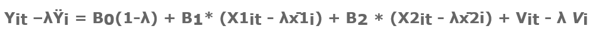

Rastgele etkili model, yatay kesit birimleri büyük bir popülasyondan rastgele seçildiğinde uygundur. Gruplar arasında bir varyans yapısı biliniyorsa, rastgele etkili model, genelleştirilmiş en küçük kareler (GLS) ile tahmin edilir. Öte yandan, varyans yapısı bilinmiyorsa, varyans yapısını tahmin etmek için uygun genelleştirilmiş en küçük kareler (FGLS) yöntemi uygundur. Rastgele etkilerin varlığı için Lagrange çarpanı (LM) testi Breusch ve Pagan (1980) tarafından tasarlanmıştır.

Sabit etkili modelle karşılaştırıldığında, rastgele etkili, ortak bir kesişmeye izin verirken, kukla değişkenler olarak belirtilmek yerine hata terimi içinde eyaletlerin heterojenliğini içerir. Her eyaletin kendi kesişim değerine sahip olduğu sabit etkili modelden farklı olarak, rastgele etkili modelinde ortak kesişim ($B_0$) tüm eyalet kesişimlerinin ortalamasıdır. Eyalete özel hata bileşeni ($\epsilon_i$), her eyaletin kesişim noktasının ortak $B_0$ kesişiminden rastgele sapmasını ölçer.

Havuzlanmış EKK’de, hata terimi ve bağımsız değişkenler arasındaki kovaryansın 0 olduğunu varsayıyoruz. Ancak bu varsayım, seri korelasyon sorununa yol açabilir, yani her periyottaki hatalar gelecek periyotlara taşındığında, verimsiz parametre tahminlerine yol açar. Rastgele etkili, bunu genelleştirilmiş en küçük kareler (GLS) yaklaşımını kullanarak, yani ağırlıkları GLS parametreleri($\lambda$) koyarak çözer.

$[0<= \lambda <=1]$

- Eğer $\lambda = 0$ -> Havuzlanmış EKK -> $Y_{it}=\beta_0+\beta_1X_{1it}+\beta_2X_{2it}+v_{it}$
- Eğer $\lambda = 1$ -> Sabit etkili model -> $Y_{it}–y_i = \beta_1(X_{1it} - x_{1i}) + \beta_1(X_{2it} - x_{2i}) + V_{it} - V_i$

```r
random <- plm(mur ~ vio + rob + incarc_rate + pop + pb1064 + pw1064 + pm1029 + avginc + density,data = weapons, index = c("stateid","year"),model ="random")
summary(random)
```

```
## Oneway (individual) effect Random Effect Model
##    (Swamy-Arora's transformation)
##
## Call:
## plm(formula = mur ~ vio + rob + incarc_rate + pop + pb1064 +
##     pw1064 + pm1029 + avginc + density, data = weapons, model = "random",
##     index = c("stateid", "year"))
##
## Balanced Panel: n = 50, T = 23, N = 1150
##
## Effects:
##                 var std.dev share
## idiosyncratic 1.186   1.089 0.402
## individual    1.764   1.328 0.598
## theta: 0.8315
##
## Residuals:
##     Min.  1st Qu.   Median  3rd Qu.     Max.
## -4.39480 -0.69519 -0.11540  0.62055  6.60758
##
## Coefficients:
##                Estimate  Std. Error z-value  Pr(>|z|)
## (Intercept) -5.20481105  2.53782118 -2.0509 0.0402769 *
## vio          0.00368387  0.00066669  5.5256 3.283e-08 ***
## rob          0.01567103  0.00157398  9.9563 < 2.2e-16 ***
## incarc_rate -0.00601682  0.00072605 -8.2870 < 2.2e-16 ***
## pop         -0.12298410  0.03553989 -3.4605 0.0005393 ***
## pb1064       0.37525416  0.08476983  4.4267 9.567e-06 ***
## pw1064       0.03146574  0.03463766  0.9084 0.3636534
## pm1029       0.28135681  0.04703987  5.9812 2.214e-09 ***
## avginc       0.17981775  0.04177922  4.3040 1.677e-05 ***
## density     -5.63835117  0.93914500 -6.0037 1.929e-09 ***
## ---
## Signif. codes:  0 '***' 0.001 '**' 0.01 '*' 0.05 '.' 0.1 ' ' 1
##
## Total Sum of Squares:    2889.7
## Residual Sum of Squares: 1538
## R-Squared:      0.46776
## Adj. R-Squared: 0.46356
## Chisq: 1001.9 on 9 DF, p-value: < 2.22e-16
```

1. Analiz sonuçlarına göre bu dönemde 10 ile 64 yaş arasındaki beyaz olan eyalet nüfusunun yüzdesi değişkeni hariç diğer değişkenlerin eyaletlerde cinayet oranı değeriyle anlamlı bir ilişkiye sahip olduğu gözlenmektedir.

   Eyaletlerdeki bir önceki yıl eyalette hapsedilme oranı ve mil kare başına nüfus değişkeninin cinayet oranı üzerinde negatif etkisi olduğu gözlemlenmiştir.
2. 10 ile 64 yaş arasındaki beyaz olan eyalet nüfusunun yüzdesi değişkeni hariç diğer değişkenlerin bireysel etkisi, p değeri 0.05’ten küçük olduğu için önemlidir.
3. $R^2$ ve Düzeltilmiş $R^2$ değerleri sırasıyla 0,46776 ve 0,46356’dır.

# 15.Hausman Test

Hausman testi, iki farklı modelin katsayı vektörlerinin farkına dayanmaktadır. Sabit veya Rastgele Etkili Model seçimine karar vermek için Hausman testi kullanılabilir. Bunun için phtest() fonksiyonunu kullanabiliriz.

$H_0$: Rastgele etkili model anlamlıdır.

$H_a$: Sabit etkili model anlamlıdır.

Benzersiz hataların bağımsız değişkenlerle ilişkili olup olmadığını test eder.

```r
phtest(fixed, random)
```

```
##
##  Hausman Test
##
## data:  mur ~ vio + rob + incarc_rate + pop + pb1064 + pw1064 + pm1029 +  ...
## chisq = 634.92, df = 9, p-value < 2.2e-16
## alternative hypothesis: one model is inconsistent
```

Görüldüğü üzere p değeri 0.05’ den küçük olup istatistiksel olarak anlamlıdır. Bu nedenle sabit etkiler modelini dikkate almamız doğru olacaktır. Yani rastgele etkiler model muhtemelen $X_{it}$ ile ilişkilidir.

# 16.Değişen Varyanslılık

Varyans sabit olmadığında doğrusal bir ilişki için değişen varyanslılık oluşur ve tahmin edici arttıkça artar. Bu gibi durumlarda, çıktıdaki standart hataya güvenilemez ancak yine de katsayılar tarafsız olacaktır.

Değişen varyanslılığı tespit etmenin en iyi yolu grafik yöntemi veya Breusch-Pagan (BP) testidir. Breusch-Pagan (BP) testi, değişen varyanslılık sürecinin bir veya daha fazla bağımsız değişkenin bir fonksiyonu olmasına izin vererek başlar ve genellikle değişen varyanslılığın modeldeki tüm bağımsız değişkenlerin doğrusal bir fonksiyonu olabileceği varsayılarak uygulanır.

BP ile değişen varyans kanıtının bulunamaması bağımsız değişken(ler) ile hata varyansı arasında doğrusal olmayan bir ilişkiyi reddedemez.

## 16.1.Grafiksel Yöntem

```r
lmMod <- lm(mur ~ vio + rob + incarc_rate + pop + pb1064 + pw1064 + pm1029 + pop + avginc + density+factor(stateid)+factor(year), data=weapons)
```

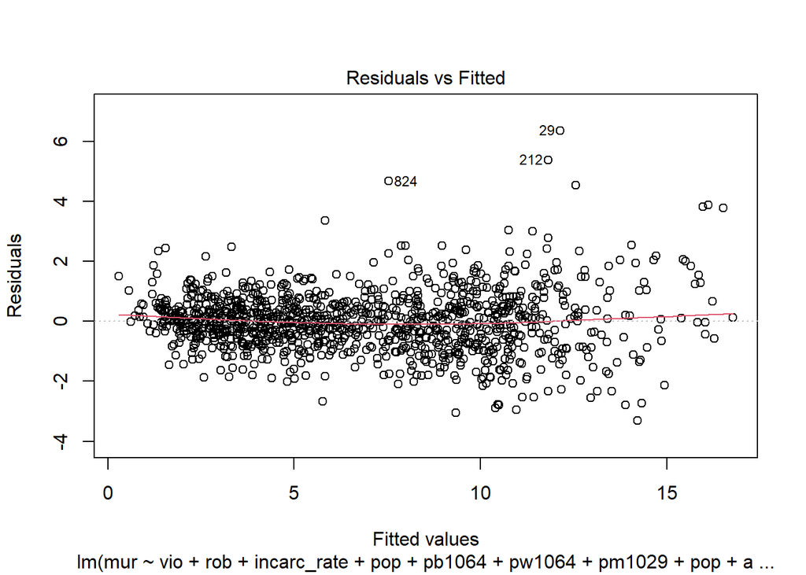

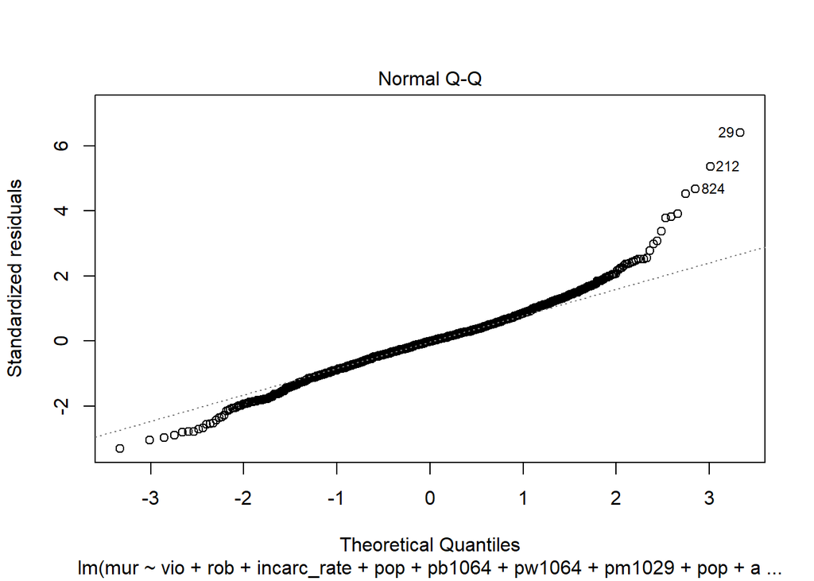

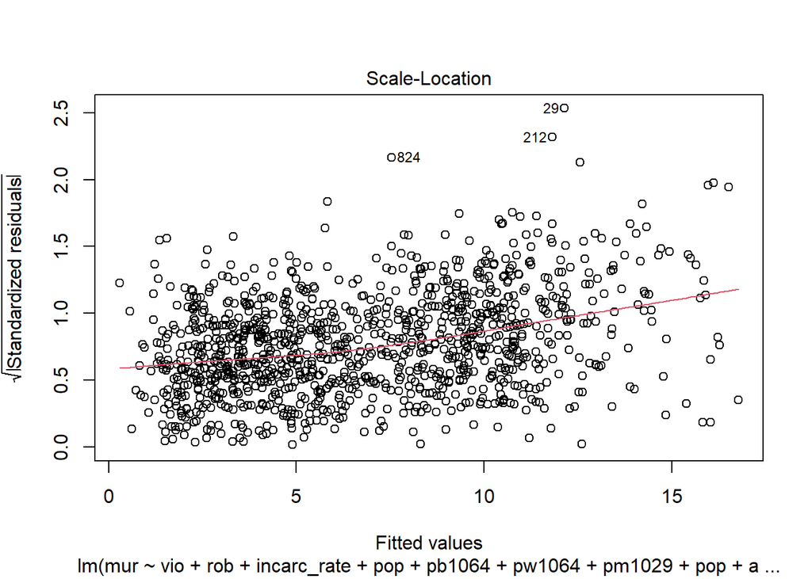

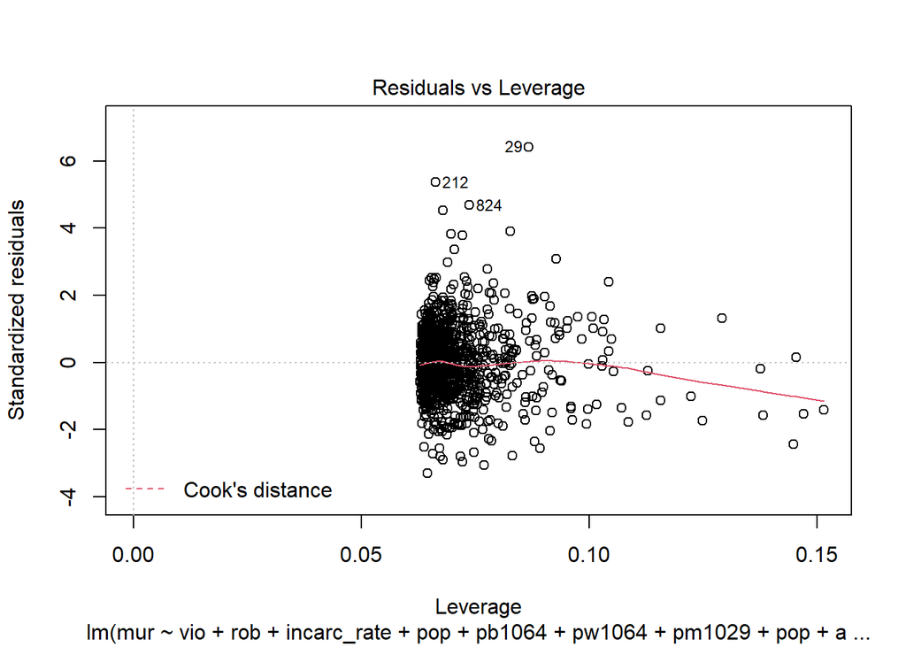

```r
plot(lmMod)
```

İlgilendiğimiz grafikler, artıklara karşı uygun değerler (fitted value) ve Y eksenindeki standartlaştırılmış artıklardır. Kesinlikle değişen varyans yoksa X ekseni aralığı boyunca tamamen rastgele, eşit bir nokta dağılımı ve düz bir kırmızı çizgi görülmelidir.

Residuals vs fitted grafiğinden fark edilebileceği gibi kırmızı çizgi düze yakın gibidir fakat tam olarak düz değildir. Grafikler yanıltıcı olabilir bu nedenle Breusch-Pagan Test uygulayarak daha doğru sonucu elde edebiliriz.

## 16.2.Breusch-Pagan (BP) Test

Breusch-Pagan (BP), lineer regresyon modelinin artıklarına bir lineer regresyon modeli uydurur (varsayılan olarak aynı açıklayıcı değişkenler ana regresyon modelinde olduğu gibi alınır) ve varyansın çok fazla ek açıklayıcı değişkenler tarafından açıklanması durumunda reddeder.

BP testi için;

$H_0$: Değişen varyans problemi yoktur.

$H_a$: Değişen varyans problemi vardır.

Breusch-Pagan (BP) testi, “lmtest” kütüphanesinde bulunan bptest() fonksiyonu kullanılarak yapılır.

```r
bptest(mur ~ vio + rob + incarc_rate + pop + pb1064 + pw1064 + pm1029 + avginc + density+factor(stateid)+factor(year), data=weapons, studentize=F)
```

```
##
##  Breusch-Pagan test
##
## data:  mur ~ vio + rob + incarc_rate + pop + pb1064 + pw1064 + pm1029 +     avginc + density + factor(stateid) + factor(year)
## BP = 669.7, df = 80, p-value < 2.2e-16
```

BP testinin sonucuna göre p değeri 0.05’ den küçük olup, tahmin değeri arttıkça kalıntıdaki varyansın değiştiğini gösterir. Bu nedenle $H_0$ hipotezi reddedilir. Değişkenler değişen varyansa sahiptir.

## 16.3.Değişen Varyanslılığı Düzeltmek için Box-Cox Dönüşümü

Veriyi normal dağılıma yaklaştırmak için Box-Cox dönüşümü yapılır.

```r
distBCMod <- caret::BoxCoxTrans(weapons$mur)
print(distBCMod)
```

```
## Box-Cox Transformation
##
## 1150 data points used to estimate Lambda
##
## Input data summary:
##    Min. 1st Qu.  Median    Mean 3rd Qu.    Max.
##   0.200   3.600   6.300   6.833   9.600  20.300
##
## Largest/Smallest: 101
## Sample Skewness: 0.558
##
## Estimated Lambda: 0.4
```

```r
weapons <- cbind(weapons, mur_new=predict(distBCMod, weapons$mur))
head(weapons)
```

```
##   stateid year   vio  mur   rob incarc_rate   pb1064   pw1064   pm1029      pop
## 1      AL 1977 414.4 14.2  96.8          83 8.384873 55.12291 18.17441 3.780403
## 2      AL 1978 419.1 13.3  99.1          94 8.352101 55.14367 17.99408 3.831838
## 3      AL 1979 413.3 13.2 109.5         144 8.329575 55.13586 17.83934 3.866248
## 4      AL 1980 448.5 13.2 132.1         141 8.408386 54.91259 17.73420 3.900368
## 5      AL 1981 470.5 11.9 126.5         149 8.483435 54.92513 17.67372 3.918531
## 6      AL 1982 447.7 10.6 112.0         183 8.514000 54.89621 17.51052 3.925229
##     avginc    density shall  mur_new
## 1 9.563148 0.07455240     0 4.725291
## 2 9.932000 0.07556673     0 4.538509
## 3 9.877028 0.07624532     0 4.517292
## 4 9.541428 0.07682881     0 4.517292
## 5 9.548351 0.07718658     0 4.232228
## 6 9.478919 0.07731851     0 3.927800
```

```r
lmMod_bc <- lm(mur_new ~ vio + rob + incarc_rate + pb1064 + pw1064 + pm1029 + pop + avginc + density+factor(stateid)+factor(year), data=weapons)
bptest(lmMod_bc)
```

```
##
##  studentized Breusch-Pagan test
##
## data:  lmMod_bc
## BP = 212.39, df = 80, p-value = 6.073e-14
```

BP testinin sonucuna göre p değeri 0.05’ den küçüktür. Bu nedenle H0 hipotezi reddedilir. Değişkenler değişen varyansa sahiptir.

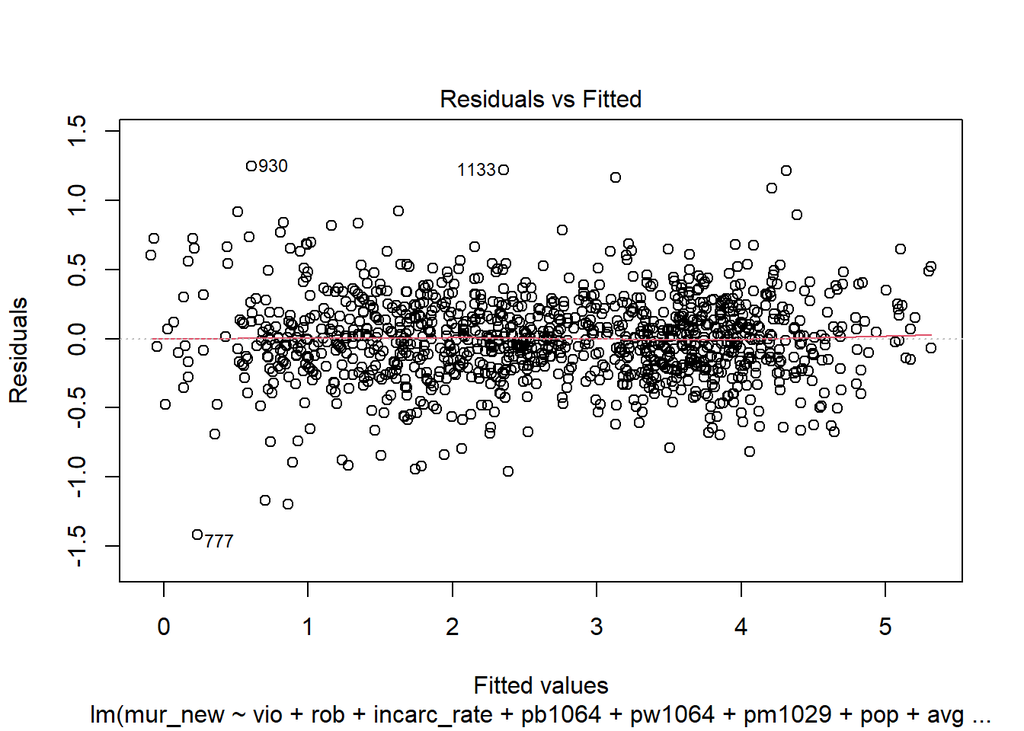

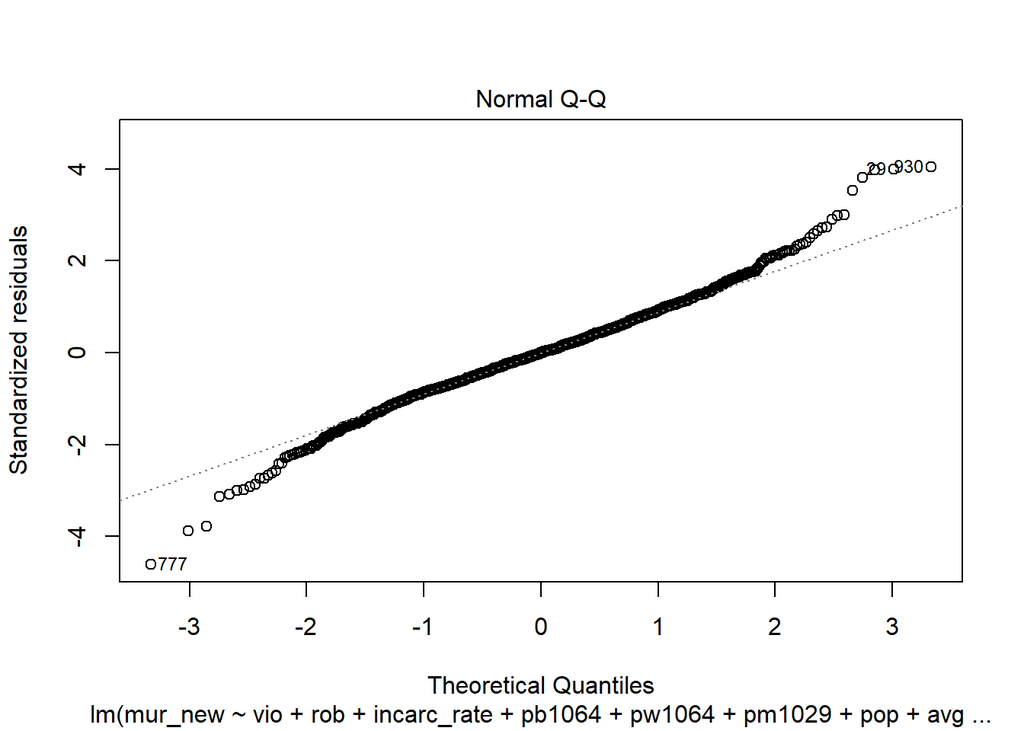

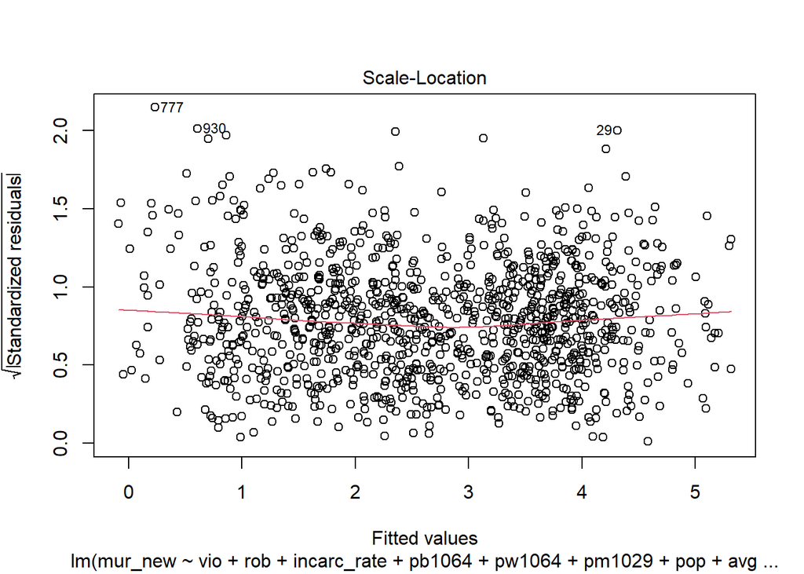

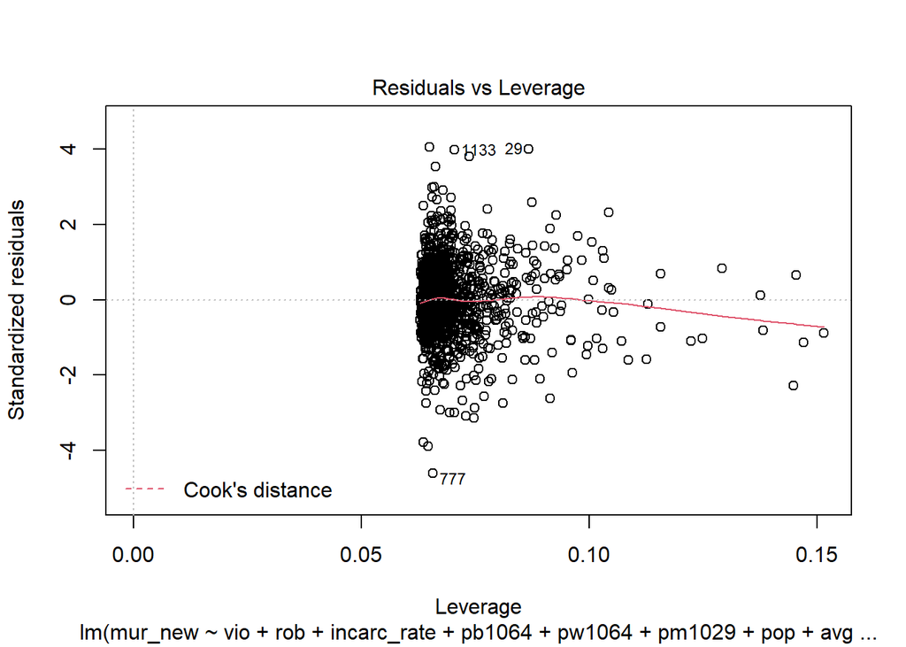

```r
plot(lmMod_bc)
```

Görüldüğü üzere Box-Cox dönüşümünden sonra, Residuals vs Fitted grafiği çok daha düz bir çizgiye sahiptir.

## 16.4.Değişen Varyanslılık Tutarlı Katsayıları

R’da coeftest() tutarlı değişen varyans katsayılarını bulmak için kullanılır. Coeftest(), temel olarak tahminleri, ilişkili standart hataları, test istatistiklerini ve p değerlerini içeren sütunları olan bir katsayı matrisi olarak “coeftest” sınıfının bir nesnesini döndürür. vcovHC, White modeline göre sabit etkili veya rastgele etkili model için parametrelerin güçlü bir kovaryans matrisini tahmin etmek için kullanılır.

coeftest, lmtest paketinde mevcuttur ve coeftest(), fitted “lm” nesnelerine uygulanabilen bir yönteme sahiptir.

$coeftest(lmobj, \space vcov=NULL, \space df=NULL, \space ...)$

Burada vcov kovaryansları, kovaryans matrisi tahminine karşılık gelen bir matris olarak veya kovaryans matris tahmincisine karşılık gelen lmobj’den hesaplayan bir fonksiyon olarak belirtir.

### 16.4.1.Orijinal Katsayılar

```r
coeftest(fixed)
```

```
##
## t test of coefficients:
##
##                Estimate  Std. Error t value  Pr(>|t|)
## vio          0.00267833  0.00066951  4.0005 6.748e-05 ***
## rob          0.01636169  0.00159576 10.2532 < 2.2e-16 ***
## incarc_rate -0.00696553  0.00073435 -9.4853 < 2.2e-16 ***
## pop         -0.41996141  0.06344867 -6.6189 5.663e-11 ***
## pb1064       0.63907169  0.13240384  4.8267 1.586e-06 ***
## pw1064       0.02826794  0.03616077  0.7817    0.4345
## pm1029       0.25521386  0.04628632  5.5138 4.382e-08 ***
## avginc       0.25187896  0.04617407  5.4550 6.058e-08 ***
## density     -8.67256486  4.43927460 -1.9536    0.0510 .
## ---
## Signif. codes:  0 '***' 0.001 '**' 0.01 '*' 0.05 '.' 0.1 ' ' 1
```

### 16.4.2.Değişen Varyanslılık Tutarlı Katsayılar

vcovHC(), regresyon modellerinde katsayı tahminlerinin kovaryans matrisinin değişen varyansla tutarlı tahmini için kullanılır.

```r
coeftest(fixed, vcovHC)
```

```
##
## t test of coefficients:
##
##               Estimate Std. Error t value  Pr(>|t|)
## vio          0.0026783  0.0011148  2.4025  0.016449 *
## rob          0.0163617  0.0022907  7.1425 1.672e-12 ***
## incarc_rate -0.0069655  0.0013171 -5.2887 1.488e-07 ***
## pop         -0.4199614  0.2815970 -1.4914  0.136157
## pb1064       0.6390717  0.3029634  2.1094  0.035137 *
## pw1064       0.0282679  0.0570914  0.4951  0.620605
## pm1029       0.2552139  0.0897563  2.8434  0.004547 **
## avginc       0.2518790  0.1121985  2.2449  0.024972 *
## density     -8.6725649 13.0972757 -0.6622  0.508005
## ---
## Signif. codes:  0 '***' 0.001 '**' 0.01 '*' 0.05 '.' 0.1 ' ' 1
```

vcovHC() işlevi, değişen varyansla tutarlı üç kovaryans tahmincisini tahmin eder;

**white1** - Genel değişen varyans için, ancak seri korelasyon yoktur. Rastgele etkiler için önerilir.

**white2** - Gruplar içinde ortak bir varyansla sınırlı “white1”dir. Rastgele etkiler için önerilir.

**arellano** - Hem değişen varyans hem de seri korelasyon. Sabit etkiler için önerilir.

### 16.4.3.Değişen Varyanslılık Tutarlı Katsayılar (Arellano)

```r
coeftest(fixed, vcovHC(fixed, method = "arellano"))
```

```
##
## t test of coefficients:
##
##               Estimate Std. Error t value  Pr(>|t|)
## vio          0.0026783  0.0011148  2.4025  0.016449 *
## rob          0.0163617  0.0022907  7.1425 1.672e-12 ***
## incarc_rate -0.0069655  0.0013171 -5.2887 1.488e-07 ***
## pop         -0.4199614  0.2815970 -1.4914  0.136157
## pb1064       0.6390717  0.3029634  2.1094  0.035137 *
## pw1064       0.0282679  0.0570914  0.4951  0.620605
## pm1029       0.2552139  0.0897563  2.8434  0.004547 **
## avginc       0.2518790  0.1121985  2.2449  0.024972 *
## density     -8.6725649 13.0972757 -0.6622  0.508005
## ---
## Signif. codes:  0 '***' 0.001 '**' 0.01 '*' 0.05 '.' 0.1 ' ' 1
```

## 16.5.Katsayıların Değişen Varyanslılık-Tutarlı (HC) Standart Hataları

Eğer bir lineer regresyon modeli varsa, $y_i$ bağımlı değişken, $\beta$ katsayı vektörü, $x_i$ k-boyutlu bağımsız değişken ve $u_i$ hata terimidir. Şu şekilde temsil edilebilir;

$y_i = x_{i}^T\beta+u_{i}$

$i = 1, . . . , n$

O halde kovaryans matrisi şu şekilde gösterilebilir:

$\psi = VAR[\hat{\beta}]= \space (X^TX)^{-1}X^T\Omega X(X^TX)^{-1}$

Hataların $u_i$ bağımsız ama potansiyel olarak değişen varyanslı olduğu varsayılırsa (tipik olarak enine kesit verileriyle ortaya çıkan bir durum), bunların kovaryans matrisi $\Omega$ köşegendir ancak sabit olmayan köşegen elemanlara sahiptir. Bu nedenle, $\Omega = diag(\widehat{}\omega_1,......,\omega_n)$ tipi bir tahminin eklenmesiyle oluşturulan çeşitli HC tahmin edicileri $\psi \widehat{} HC$ önerilmiştir. Bu tahmin ediciler, $\Omega_i$ seçimlerinde farklılık gösterir, en önemli durumlara genel bir bakış aşağıda verilmiştir;

$const: \space w_i= \hat{\sigma}^2$

$HC0: \space w_i= \hat{u_i}^2$

$HC1: \space w_i= \frac{n}{n-k}\hat{u_i}^2$

$HC2: \space w_i= \frac{\hat{u_i}^2}{1-h_i}$

$HC3: \space w_i= \frac{\hat{u_i}^2}{(1-h_i)^2}$

$HC4: \space w_i= \frac{\hat{u_i}^2}{(1-h_i)^{\delta_i}}$

```r
t(sapply(c("HC0", "HC1", "HC2", "HC3", "HC4"),
           function(x) sqrt(diag(vcovHC(fixed, method = "arellano", type = x)))))
```

```
##             vio         rob incarc_rate       pop    pb1064     pw1064
## HC0 0.001114802 0.002290748 0.001317058 0.2815970 0.3029634 0.05709138
## HC1 0.001119190 0.002299765 0.001322242 0.2827054 0.3041559 0.05731610
## HC2 0.001120307 0.002304124 0.001326872 0.2862903 0.3071493 0.05740856
## HC3 0.001125857 0.002317689 0.001336927 0.2911089 0.3114648 0.05772968
## HC4 0.001124304 0.002318967 0.001344936 0.2990818 0.3182276 0.05781780
##         pm1029    avginc  density
## HC0 0.08975626 0.1121985 13.09728
## HC1 0.09010956 0.1126401 13.14883
## HC2 0.09030208 0.1128159 13.23144
## HC3 0.09085594 0.1134354 13.36783
## HC4 0.09088271 0.1131779 13.50272
```

- HC0 - değişen varyans tutarlılığı. Varsayılan.
- HC1,HC2,HC3 – Küçük örnekler için önerilir. HC3, etkili gözlemlere daha az ağırlık verir.
- HC4 - etkili gözlemlere sahip küçük örneklerdir HAC - değişen varyans ve otokorelasyon tutarlıdır.

# 17.Kaynakça

https://www.princeton.edu/~otorres/Panel101R.pdf

https://cran.r-project.org/web/packages/sandwich/vignettes/sandwich.pdf

https://www.r-bloggers.com/2016/01/how-to-detect-heteroscedasticity-and-rectify-it/

https://uclspp.github.io/PUBL0055/seminar7.html

https://uclspp.github.io/PUBL0055/lecture_slides/lecture7.pdf

https://www.econometrics-with-r.org/10.1-panel-data.html

https://www.istmer.com/panel-veri-analizi-nedir/

Atatürk Üniversitesi İktisadi ve İdari Bilimler Dergisi, Cilt: 32 2018 Sayı: 4 (PANEL VERİ ANALİZİ VE KÜMELEME YÖNTEMİ İLE TÜRKİYE’DE KONUT TALEBİNİN İNCELENMESİ) -Cahit ÇELİK -Gülsen KIRAL https://dergipark.org.tr/tr/download/article-file/548380

İstanbul Üniversietsi AUZEF - “Panel Veri Analizi” -PROF. DR. FERDA YERDELEN TATOĞLU http://auzefkitap.istanbul.edu.tr/kitap/ekonometri_ue/panelverianalizi.pdf